# DATA 606 Data Project

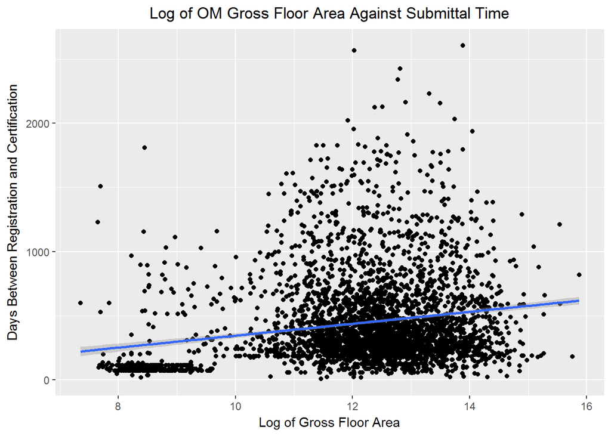

```r
ggplot(completed_projects_OM_V3, aes(y = SubmittalTime, x = log(GrossSqFoot))) + geom_point() +
    geom_smooth(method = lm, fullrange = TRUE) + labs(x = "Log of Gross Floor Area", y = "Days Between Registration and Certification") +
    ggtitle("Log of OM Gross Floor Area Against Submittal Time") + theme(plot.title = element_text(hjust = 0.5))
```

As we can see from the R-square values (BD+C - 0.01, ID+C - 0.19, OM - 0.04), these models do not appear to be great predictors of submitall time but do produce statistically significant positive prediction slopes. While these results do not appear to be of much use at the moment, we will continue the analysis and validate the models by checking the following asusmptions:

1. the residuals of the model are nearly normal

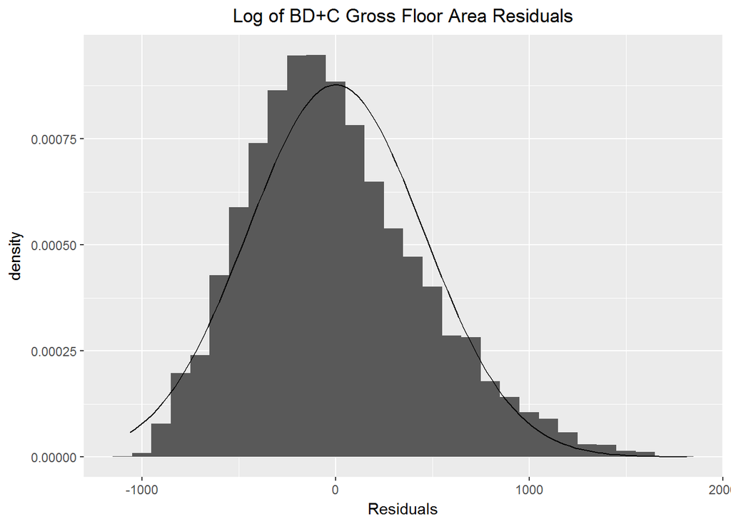

```r
# BDC
ggplot(data = gf_lm_BDC_V3, aes(x = resid(gf_lm_BDC_V3))) + geom_histogram(binwidth = 100,
    position = "identity", aes(y = ..density..)) + stat_function(fun = dnorm, color = "black",
    args = list(mean = mean(gf_lm_BDC_V3$residuals), sd(gf_lm_BDC_V3$residuals))) + labs(x = "Residuals") +
    ggtitle("Log of BD+C Gross Floor Area Residuals") + theme(plot.title = element_text(hjust = 0.5))
```

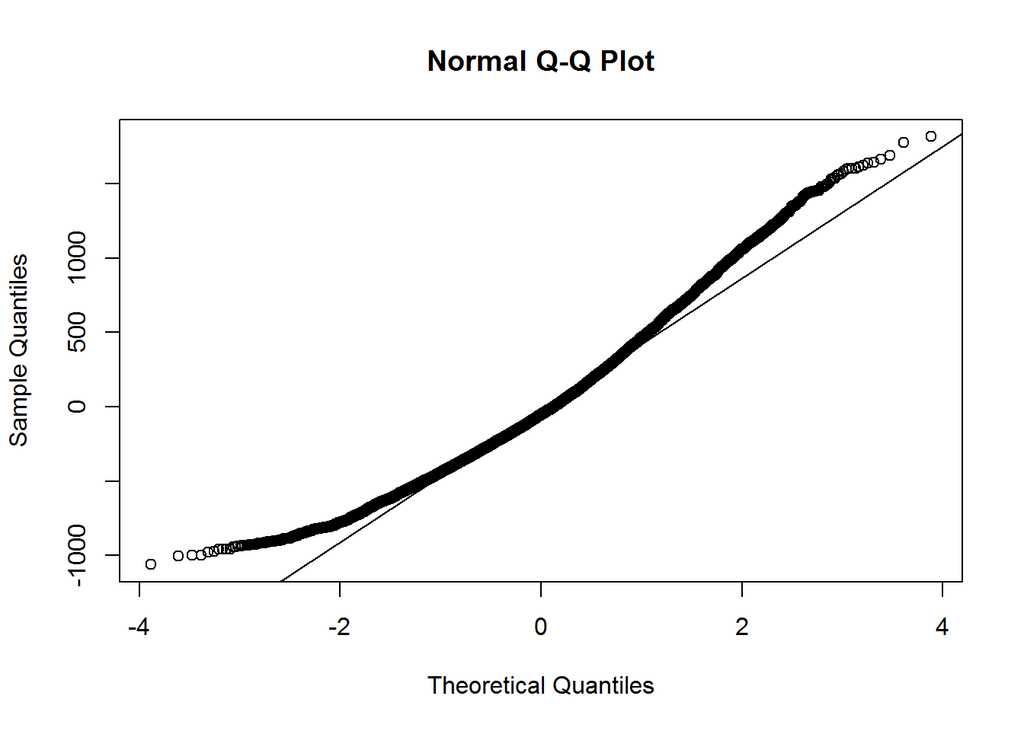

```r
qqnorm(gf_lm_BDC_V3$residuals)
qqline(gf_lm_BDC_V3$residuals)
```

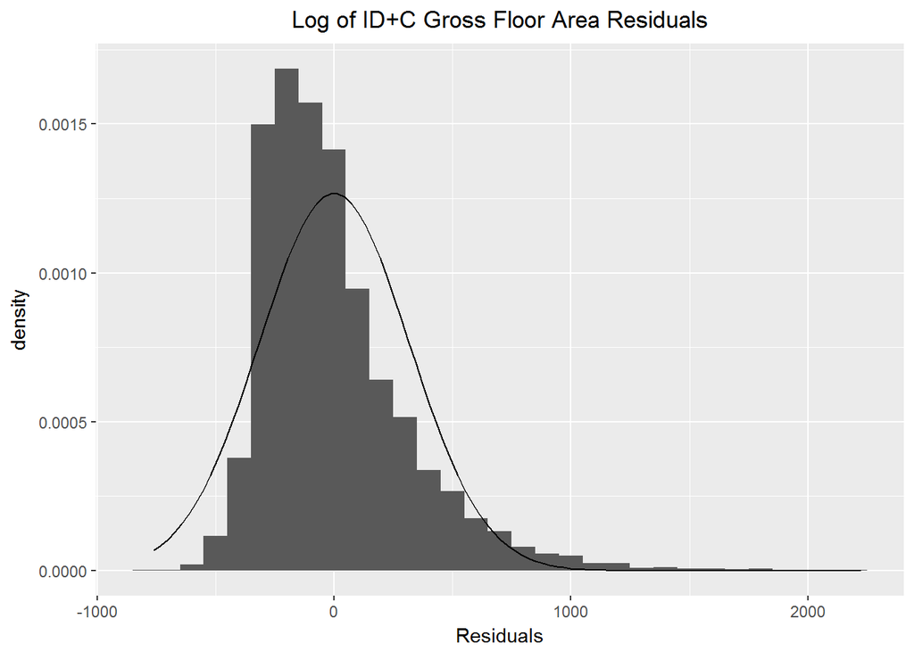

```r
# IDC
ggplot(data = gf_lm_IDC_V3, aes(x = resid(gf_lm_IDC_V3))) + geom_histogram(binwidth = 100,
    position = "identity", aes(y = ..density..)) + stat_function(fun = dnorm, color = "black",
    args = list(mean = mean(gf_lm_IDC_V3$residuals), sd(gf_lm_IDC_V3$residuals))) + labs(x = "Residuals") +
    ggtitle("Log of ID+C Gross Floor Area Residuals") + theme(plot.title = element_text(hjust = 0.5))
```

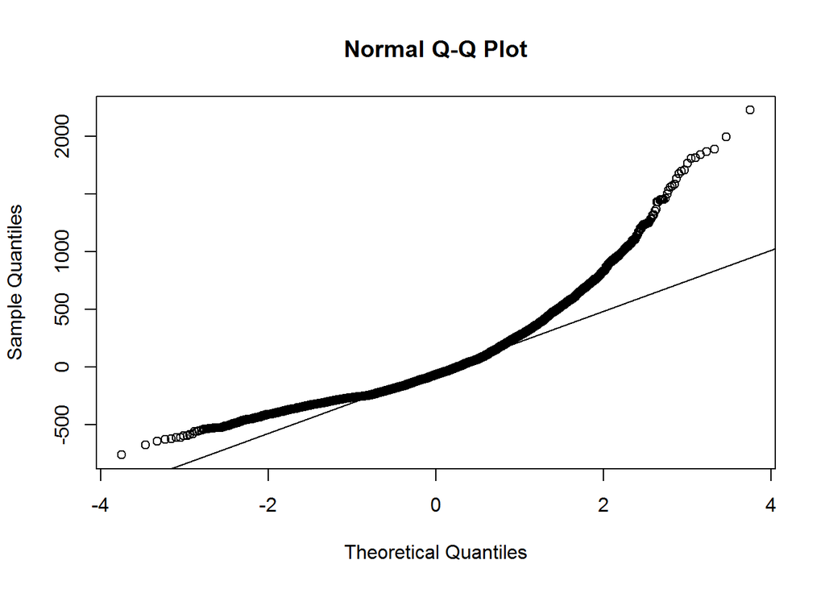

```r
qqnorm(gf_lm_IDC_V3$residuals)
qqline(gf_lm_IDC_V3$residuals)
```

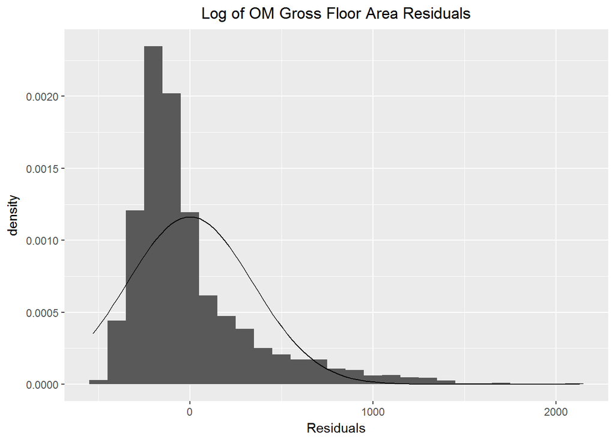

```r
# OM
ggplot(data = gf_lm_OM_V3, aes(x = resid(gf_lm_OM_V3))) + geom_histogram(binwidth = 100, position = "identity",
    aes(y = ..density..)) + stat_function(fun = dnorm, color = "black", args = list(mean = mean(gf_lm_OM_V3$residuals),
    sd(gf_lm_OM_V3$residuals))) + labs(x = "Residuals") + ggtitle("Log of OM Gross Floor Area Residuals") +
    theme(plot.title = element_text(hjust = 0.5))
```

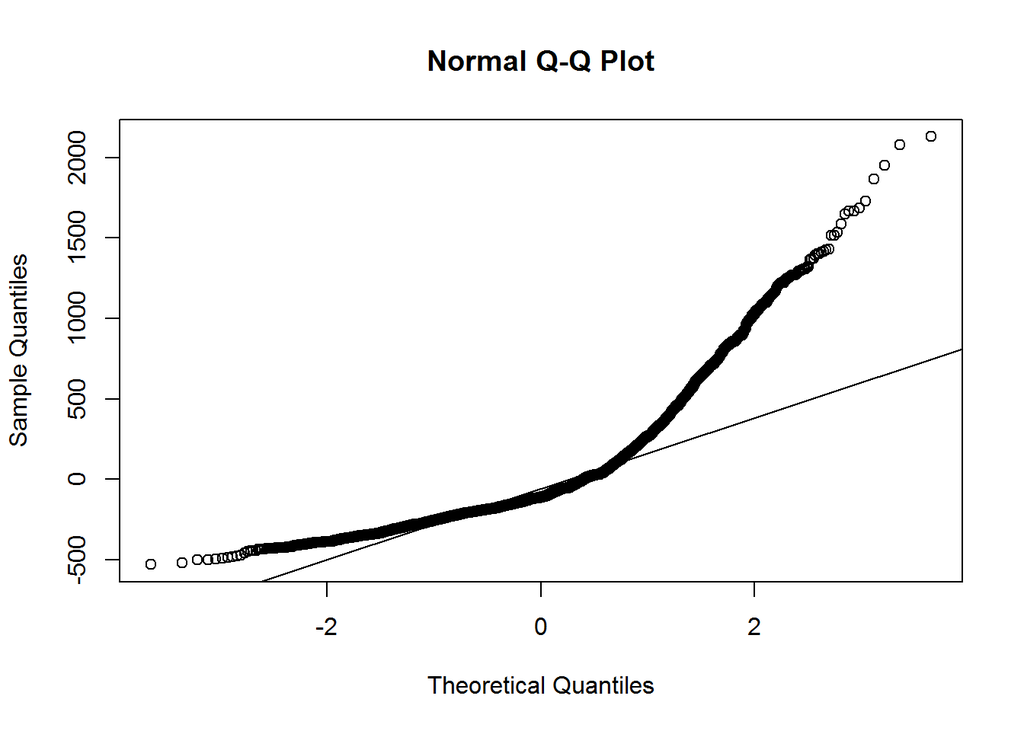

```r
qqnorm(gf_lm_OM_V3$residuals)
qqline(gf_lm_OM_V3$residuals)
```

2. the variability of the residuals is nearly constant

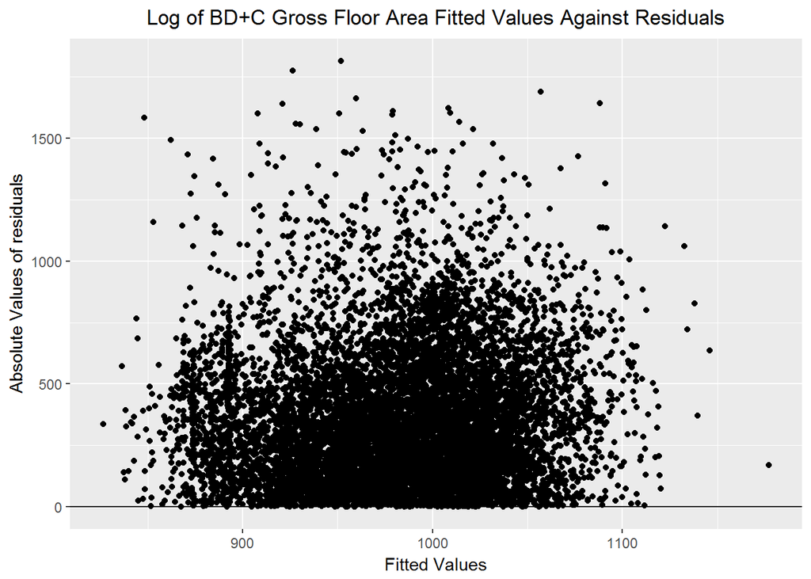

```r
# BDC
ggplot(gf_lm_BDC_V3, aes(y = abs(resid(gf_lm_BDC_V3)), x = gf_lm_BDC_V3$fitted.values)) + geom_point() +
    geom_hline(yintercept = 0) + labs(x = "Fitted Values", y = "Absolute Values of residuals") +
    ggtitle("Log of BD+C Gross Floor Area Fitted Values Against Residuals") + theme(plot.title = element_text(hjust = 0.5))
```

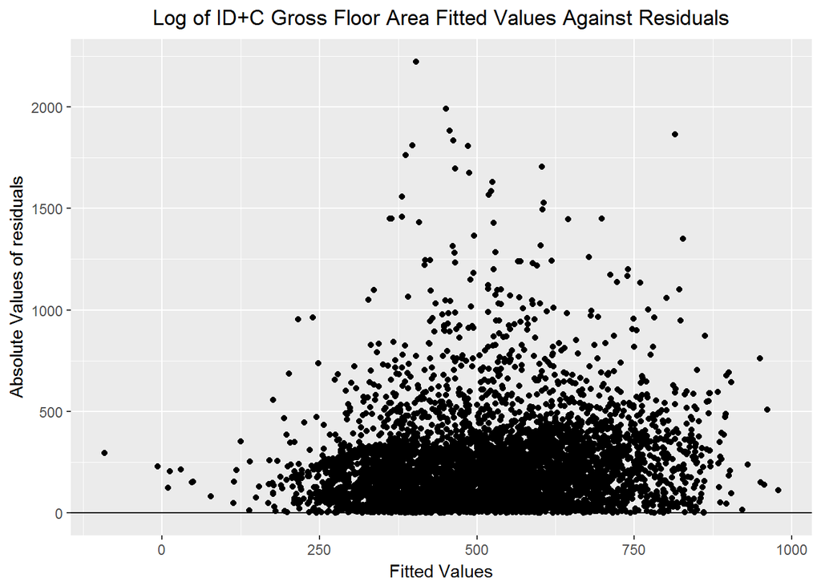

```r
# IDC
ggplot(gf_lm_IDC_V3, aes(y = abs(resid(gf_lm_IDC_V3)), x = gf_lm_IDC_V3$fitted.values)) + geom_point() +
    geom_hline(yintercept = 0) + labs(x = "Fitted Values", y = "Absolute Values of residuals") +
    ggtitle("Log of ID+C Gross Floor Area Fitted Values Against Residuals") + theme(plot.title = element_text(hjust = 0.5))
```

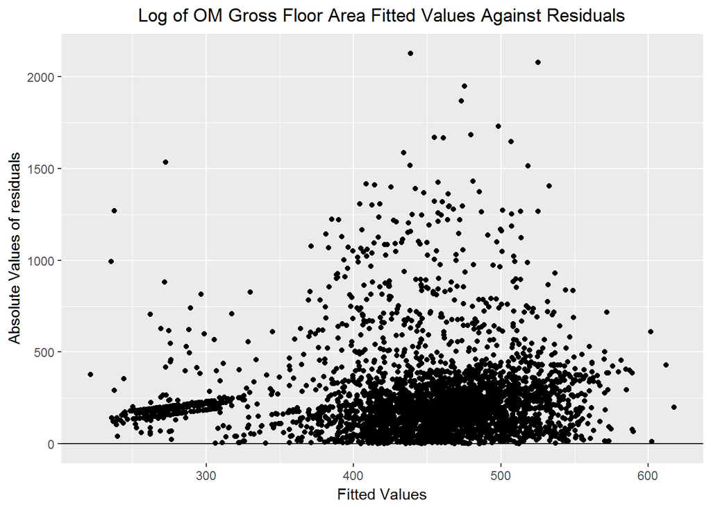

```r
# OM
ggplot(gf_lm_OM_V3, aes(y = abs(resid(gf_lm_OM_V3)), x = gf_lm_OM_V3$fitted.values)) + geom_point() +
    geom_hline(yintercept = 0) + labs(x = "Fitted Values", y = "Absolute Values of residuals") +
    ggtitle("Log of OM Gross Floor Area Fitted Values Against Residuals") + theme(plot.title = element_text(hjust = 0.5))
```

3. the residuals are independent

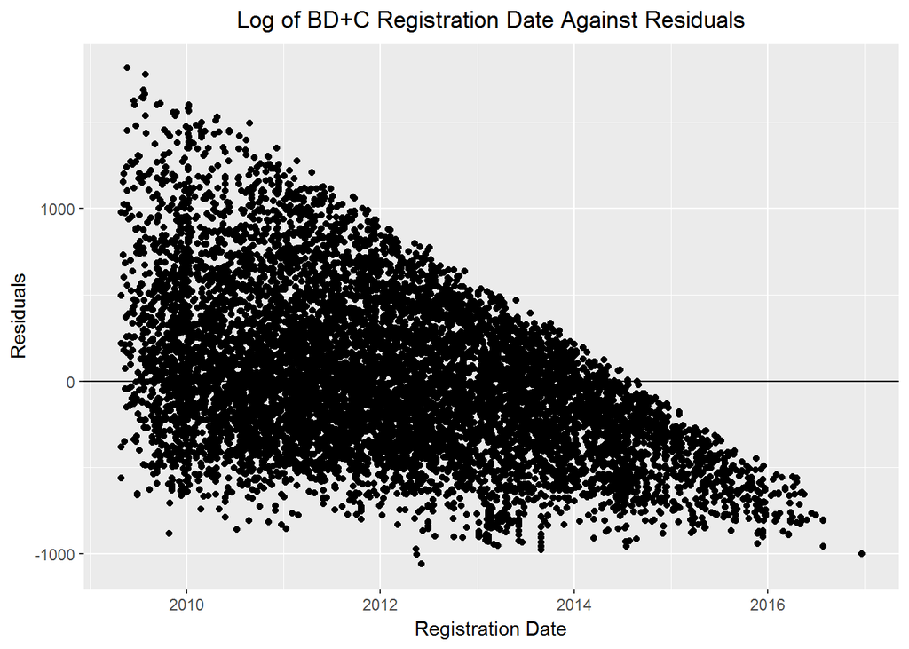

```r
# BDC
ggplot(gf_lm_BDC_V3, aes(y = resid(gf_lm_BDC_V3), x = completed_projects_BDC_V3$RegistrationDate)) +
    geom_point() + geom_hline(yintercept = 0) + labs(x = "Registration Date", y = "Residuals") +
    ggtitle("Log of BD+C Registration Date Against Residuals") + theme(plot.title = element_text(hjust = 0.5))
```

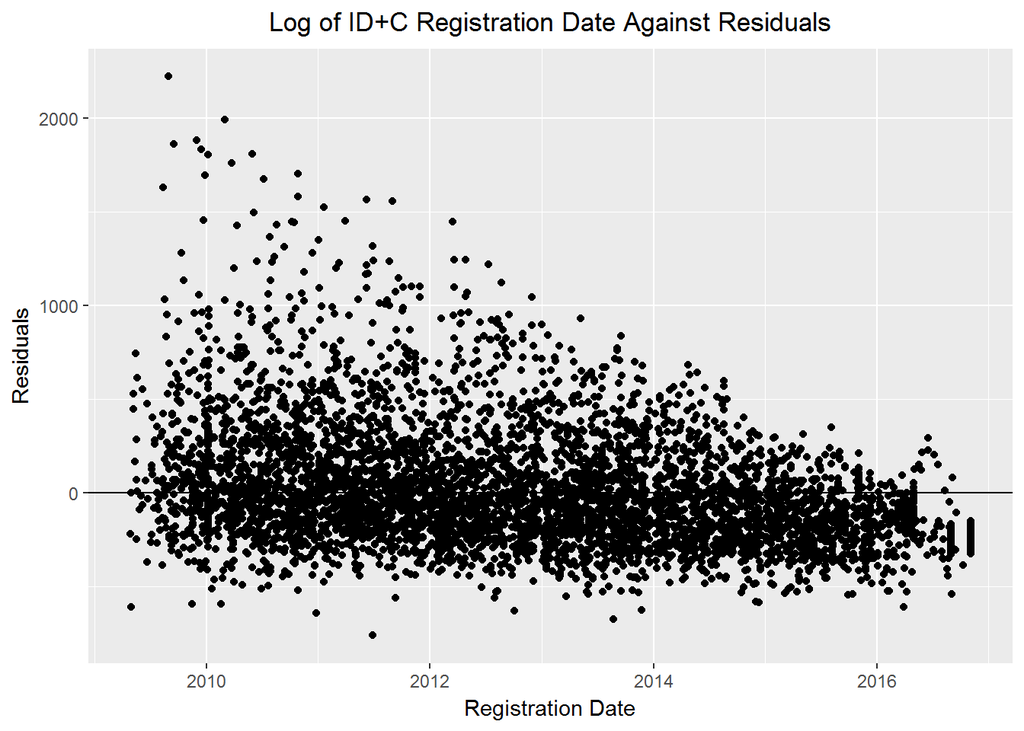

```r
# IDC
ggplot(gf_lm_IDC_V3, aes(y = resid(gf_lm_IDC_V3), x = completed_projects_IDC_V3$RegistrationDate)) +
    geom_point() + geom_hline(yintercept = 0) + labs(x = "Registration Date", y = "Residuals") +
    ggtitle("Log of ID+C Registration Date Against Residuals") + theme(plot.title = element_text(hjust = 0.5))
```

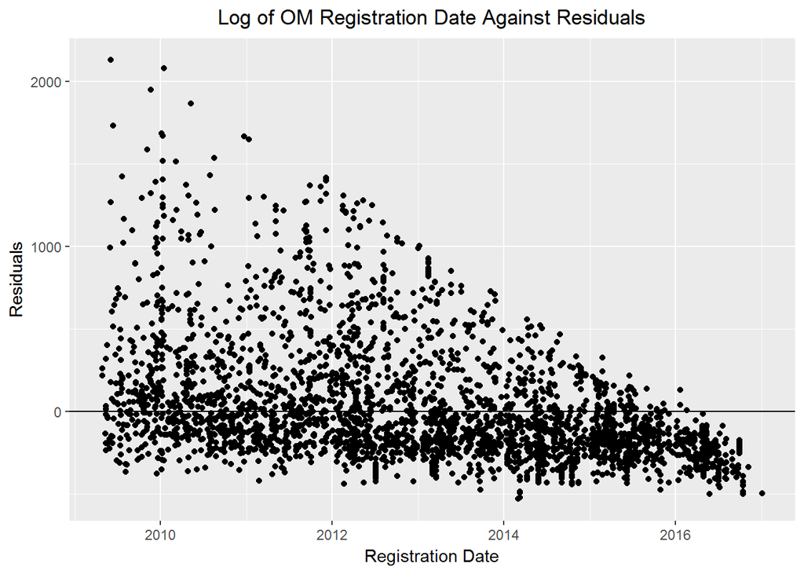

```r
# OM
ggplot(gf_lm_OM_V3, aes(y = resid(gf_lm_OM_V3), x = completed_projects_OM_V3$RegistrationDate)) +
    geom_point() + geom_hline(yintercept = 0) + labs(x = "Registration Date", y = "Residuals") +
    ggtitle("Log of OM Registration Date Against Residuals") + theme(plot.title = element_text(hjust = 0.5))
```

4. each variable is linearly related to the outcome.

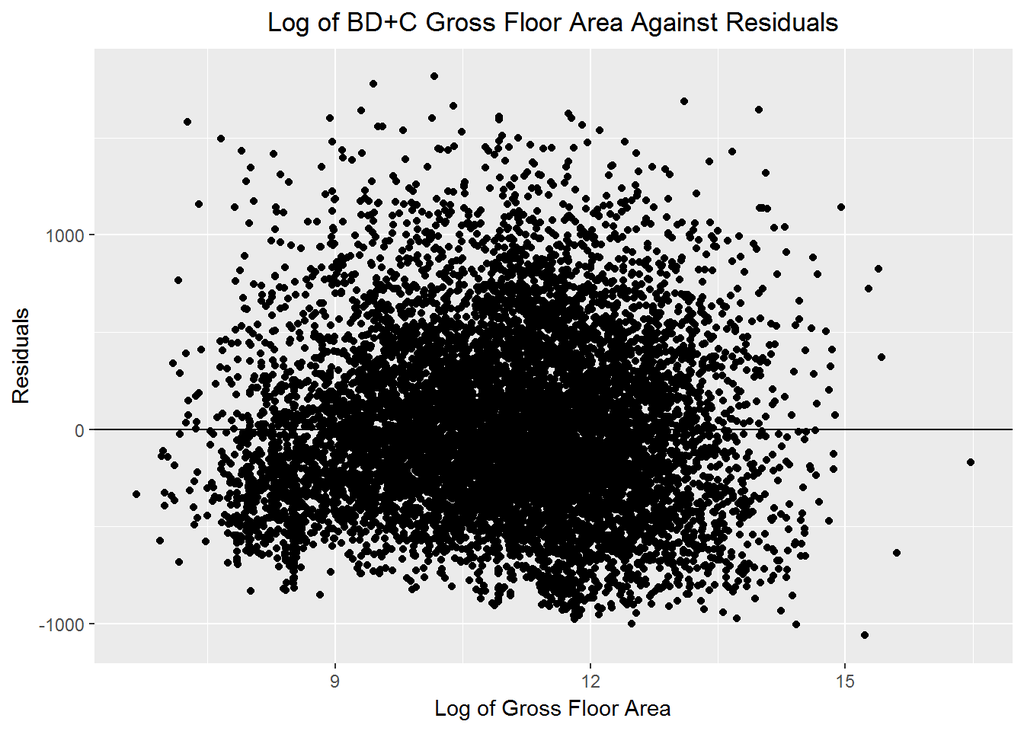

```r
# BDC
ggplot(gf_lm_BDC_V3, aes(y = resid(gf_lm_BDC_V3), x = log(completed_projects_BDC_V3$GrossSqFoot))) +
    geom_point() + geom_hline(yintercept = 0) + labs(x = "Log of Gross Floor Area", y = "Residuals") +
    ggtitle("Log of BD+C Gross Floor Area Against Residuals") + theme(plot.title = element_text(hjust = 0.5))
```

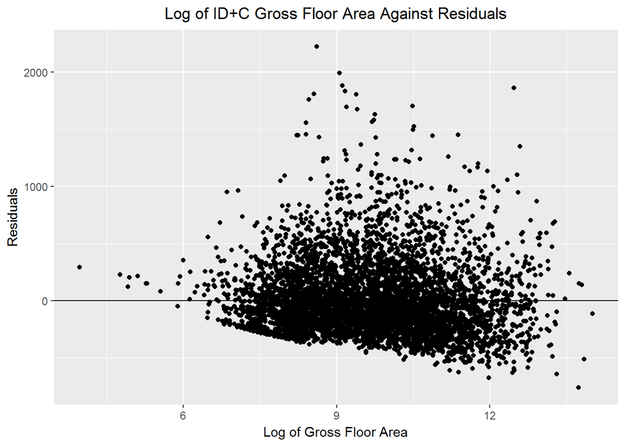

```r
# IDC
ggplot(gf_lm_IDC_V3, aes(y = resid(gf_lm_IDC_V3), x = log(completed_projects_IDC_V3$GrossSqFoot))) +
    geom_point() + geom_hline(yintercept = 0) + labs(x = "Log of Gross Floor Area", y = "Residuals") +
    ggtitle("Log of ID+C Gross Floor Area Against Residuals") + theme(plot.title = element_text(hjust = 0.5))
```

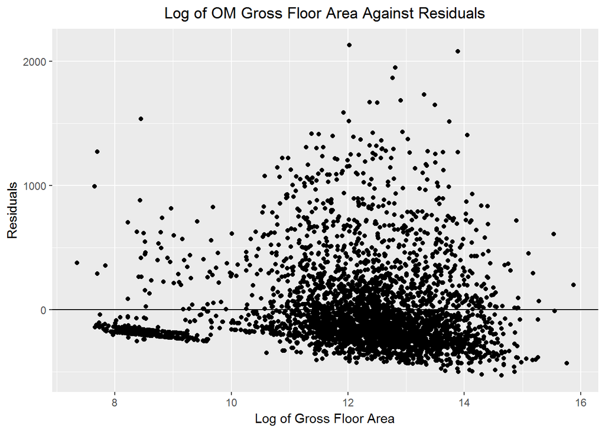

```r
# OM
ggplot(gf_lm_OM_V3, aes(y = resid(gf_lm_OM_V3), x = log(completed_projects_OM_V3$GrossSqFoot))) +
    geom_point() + geom_hline(yintercept = 0) + labs(x = "Log of Gross Floor Area", y = "Residuals") +
    ggtitle("Log of OM Gross Floor Area Against Residuals") + theme(plot.title = element_text(hjust = 0.5))
```

The histogram shows that the data do not exactly follow a normal distribution. From the normal probability plot it appears the data is narrower than a typical normal distribution (short tails) and has a right skew for the BD+C and ID+C data sets. The OM data set appear to have a right skew and it is unclear if there are short tails. The residuals appear to be independent from the registration date vs residuals and gross floor area vs residuals graphs. Note that there is apparent decrease of the maximum possible value in the registration date vs residuals graph. This is due to the fact that older projects have a larger window to certify since they have been open longer, thus they can have a larger maximum possible residual and the newer projects only represent projects that have certified early. Therefore, there may be some leverage points at both ends of project registration dates. In addition to the issues with skewness and leverage points, each model reports a low r-squared value. Even if all the assumptions were completely validated, the model would only explain 1.28% of the variability for the BD+C data set, 19.35% of the variability for the ID+C data set, and 3.85% of the variability for the OM data set, which is much too small to be considered useful.

As previously noted, the gross floor is not a great predictor variable of the time it takes for a project to certify; however, we can perform a multi-linear regression analysis, which uses more than one predictor variable, to estimate the submittal times. In order to do this, we must filter the data to ensure there are sufficient values in each predictor variable we want to use and then perform an analysis. For this study, we will start with the following variables since they are known at the time of registration: confidential status (Isconfidential), Country (Note - any countries that only had a small number of submittals have been grouped into an “other” category), Rating System Family, owner types (OwnerTypesAdj - Note - the number of categories has been significantly reduced for meaningfullness), and gross floor area (GrossSqFoot - Note this variable has been log() transformed).

```r
# Make sure all columns have good data and that v4, ND, and Homes projects are excluded due
# to small size.  Only v3 since that is what we want to guess.
filtered_projects <- subset(project_data_adjusted, !(identical(project_data_adjusted$RatingSystemFamily,
    character(0))) & !(is.na(project_data_adjusted$RatingSystemFamily)) & !(project_data_adjusted$RatingSystemFamily ==
    "ND") & !(project_data_adjusted$RatingSystemFamily == "Homes") & project_data_adjusted$Platform ==
    "v3" & project_data_adjusted$GrossSqFoot > 0)

# Remove all NAs that are present
filtered_projects_lm <- subset(filtered_projects, filtered_projects$SubmittalTime > 0 & !(is.na(filtered_projects$Isconfidential)) &
    !(is.na(filtered_projects$Country)) & !(is.na(filtered_projects$RatingSystemFamily)) &
    !(is.na(filtered_projects$Platform)) & !(is.na(filtered_projects$OwnerTypesAdj)) & !(is.na(filtered_projects$GrossSqFoot)))

# Relevel countries so that US is the reference (base) value in the linear regression.
filtered_projects_lm$Country <- as.factor(filtered_projects_lm$Country)
filtered_projects_lm$Country <- relevel(filtered_projects_lm$Country, ref = "US")

# Filter out the countries with only a few projects
country_count <- data.frame(names(table(filtered_projects_lm$Country)), unname(table(filtered_projects_lm$Country)))
country_count_small <- subset(country_count, Freq > 99)
names(country_count_small) <- c("Country", "Var1", "Freq")

filtered_projects_lm$CountryAdj <- sapply(filtered_projects_lm$Country, function(x) {
    x <- as.character(country_count_small[which(country_count_small$Country == x), "Country"][1])
    ifelse(is.na(x), "Other", x)
})
# Relevel adjusted countries so that US is the reference (base) value in the linear
# regression.
filtered_projects_lm$CountryAdj <- as.factor(filtered_projects_lm$CountryAdj)
filtered_projects_lm$CountryAdj <- relevel(filtered_projects_lm$CountryAdj, ref = "US")
```

Now, by using backward elimination and forward selection, we can determine the best combination of predictor variables.

```r
ST_lm <- lm(SubmittalTime ~ Isconfidential + CountryAdj + RatingSystemFamily + OwnerTypesAdj +
    log(GrossSqFoot), data = filtered_projects_lm)
summary(ST_lm)
```

```
##
## Call:
## lm(formula = SubmittalTime ~ Isconfidential + CountryAdj + RatingSystemFamily +
##     OwnerTypesAdj + log(GrossSqFoot), data = filtered_projects_lm)
##
## Residuals:
##      Min       1Q   Median       3Q      Max
## -1061.30  -245.14   -68.23   177.41  2220.99
##
## Coefficients: (1 not defined because of singularities)
##                         Estimate Std. Error t value Pr(>|t|)
## (Intercept)              100.196     24.023   4.171 3.05e-05 ***
## IsconfidentialYes        139.980     14.285   9.799  < 2e-16 ***
## CountryAdjAE             -90.349     36.697  -2.462 0.013825 *
## CountryAdjBR              77.549     21.030   3.688 0.000227 ***
## CountryAdjCA            -455.477     24.687 -18.450  < 2e-16 ***
## CountryAdjCL              28.875     33.388   0.865 0.387139
## CountryAdjCN             -96.032     13.753  -6.983 2.99e-12 ***
## CountryAdjDE             -84.094     27.535  -3.054 0.002261 **
## CountryAdjES             -10.134     30.734  -0.330 0.741605
## CountryAdjFI            -109.847     33.972  -3.233 0.001225 **
## CountryAdjHK              -4.468     34.413  -0.130 0.896697
## CountryAdjIN             -97.951     19.213  -5.098 3.46e-07 ***
## CountryAdjIT             -91.807     35.571  -2.581 0.009861 **
## CountryAdjMX             -19.094     26.010  -0.734 0.462899
## CountryAdjOther          -22.172     10.491  -2.113 0.034578 *
## CountryAdjSE            -129.528     25.241  -5.132 2.90e-07 ***
## CountryAdjTR            -179.954     27.466  -6.552 5.83e-11 ***
## RatingSystemFamilyIDC   -302.293      7.285 -41.498  < 2e-16 ***
## RatingSystemFamilyOM    -516.888      7.994 -64.656  < 2e-16 ***
## OwnerTypesAdjcorporate    18.256     12.818   1.424 0.154390
## OwnerTypesAdjeducation   362.261     15.219  23.804  < 2e-16 ***
## OwnerTypesAdjgovernment  327.729     15.057  21.766  < 2e-16 ***
## OwnerTypesAdjindividual  164.699     26.565   6.200 5.77e-10 ***
## OwnerTypesAdjinvestor      5.140     14.768   0.348 0.727814
## OwnerTypesAdjnon-profit  225.282     19.158  11.759  < 2e-16 ***
## OwnerTypesAdjother            NA         NA      NA       NA
## log(GrossSqFoot)          68.512      1.912  35.839  < 2e-16 ***
## ---
## Signif. codes:  0 '***' 0.001 '**' 0.01 '*' 0.05 '.' 0.1 ' ' 1
##
## Residual standard error: 372.3 on 19230 degrees of freedom
## Multiple R-squared:  0.3996, Adjusted R-squared:  0.3988
## F-statistic: 511.9 on 25 and 19230 DF,  p-value: < 2.2e-16
```

```r
# Backward Radj - First step remove Isconfidential
ST_lm_b <- lm(SubmittalTime ~ CountryAdj + RatingSystemFamily + OwnerTypesAdj + log(GrossSqFoot),
    data = filtered_projects_lm)
summary(ST_lm_b)
```

```
##
## Call:
## lm(formula = SubmittalTime ~ CountryAdj + RatingSystemFamily +
##     OwnerTypesAdj + log(GrossSqFoot), data = filtered_projects_lm)
##
## Residuals:
##      Min       1Q   Median       3Q      Max
## -1061.30  -245.14   -68.23   177.41  2220.99
##
## Coefficients:
##                         Estimate Std. Error t value Pr(>|t|)
## (Intercept)              240.176     22.766  10.550  < 2e-16 ***
## CountryAdjAE             -90.349     36.697  -2.462 0.013825 *
## CountryAdjBR              77.549     21.030   3.688 0.000227 ***
## CountryAdjCA            -455.477     24.687 -18.450  < 2e-16 ***
## CountryAdjCL              28.875     33.388   0.865 0.387139
## CountryAdjCN             -96.032     13.753  -6.983 2.99e-12 ***
## CountryAdjDE             -84.094     27.535  -3.054 0.002261 **
## CountryAdjES             -10.134     30.734  -0.330 0.741605
## CountryAdjFI            -109.847     33.972  -3.233 0.001225 **
## CountryAdjHK              -4.468     34.413  -0.130 0.896697
## CountryAdjIN             -97.951     19.213  -5.098 3.46e-07 ***
## CountryAdjIT             -91.807     35.571  -2.581 0.009861 **
## CountryAdjMX             -19.094     26.010  -0.734 0.462899
## CountryAdjOther          -22.172     10.491  -2.113 0.034578 *
## CountryAdjSE            -129.528     25.241  -5.132 2.90e-07 ***
## CountryAdjTR            -179.954     27.466  -6.552 5.83e-11 ***
## RatingSystemFamilyIDC   -302.293      7.285 -41.498  < 2e-16 ***
## RatingSystemFamilyOM    -516.888      7.994 -64.656  < 2e-16 ***
## OwnerTypesAdjcorporate  -121.724      8.460 -14.387  < 2e-16 ***
## OwnerTypesAdjeducation   222.281     11.694  19.007  < 2e-16 ***
## OwnerTypesAdjgovernment  187.749     11.586  16.204  < 2e-16 ***
## OwnerTypesAdjindividual   24.718     24.793   0.997 0.318788
## OwnerTypesAdjinvestor   -134.840     11.257 -11.978  < 2e-16 ***
## OwnerTypesAdjnon-profit   85.301     16.514   5.165 2.42e-07 ***
## OwnerTypesAdjother      -139.980     14.285  -9.799  < 2e-16 ***
## log(GrossSqFoot)          68.512      1.912  35.839  < 2e-16 ***
## ---
## Signif. codes:  0 '***' 0.001 '**' 0.01 '*' 0.05 '.' 0.1 ' ' 1
##
## Residual standard error: 372.3 on 19230 degrees of freedom
## Multiple R-squared:  0.3996, Adjusted R-squared:  0.3988
## F-statistic: 511.9 on 25 and 19230 DF,  p-value: < 2.2e-16
```

```r
# #Forward ST_lm_f <- lm(SubmittalTime ~ Isconfidential, data = filtered_projects_lm)
# summary(ST_lm_f) ST_lm_f <- lm(SubmittalTime ~ CountryAdj, data = filtered_projects_lm)
# summary(ST_lm_f) ST_lm_f <- lm(SubmittalTime ~ RatingSystemFamily, data =
# filtered_projects_lm) summary(ST_lm_f) ST_lm_f <- lm(SubmittalTime ~ OwnerTypesAdj, data
# = filtered_projects_lm) summary(ST_lm_f) ST_lm_f <- lm(SubmittalTime ~ log(GrossSqFoot),
# data = filtered_projects_lm) summary(ST_lm_f) #Forward pick RatingSystemFamily ST_lm_f <-
# lm(SubmittalTime ~ RatingSystemFamily + Isconfidential, data = filtered_projects_lm)
# summary(ST_lm_f) ST_lm_f <- lm(SubmittalTime ~ RatingSystemFamily + CountryAdj, data =
# filtered_projects_lm) summary(ST_lm_f) ST_lm_f <- lm(SubmittalTime ~ RatingSystemFamily +
# OwnerTypesAdj, data = filtered_projects_lm) summary(ST_lm_f) ST_lm_f <- lm(SubmittalTime
# ~ RatingSystemFamily + log(GrossSqFoot), data = filtered_projects_lm) summary(ST_lm_f)
# #Forward pick RatingSystemFamily and OwnerTypesAdj ST_lm_f <- lm(SubmittalTime ~
# RatingSystemFamily + OwnerTypesAdj + Isconfidential, data = filtered_projects_lm)
# summary(ST_lm_f) ST_lm_f <- lm(SubmittalTime ~ RatingSystemFamily + OwnerTypesAdj +
# CountryAdj, data = filtered_projects_lm) summary(ST_lm_f) ST_lm_f <- lm(SubmittalTime ~
# RatingSystemFamily + OwnerTypesAdj + log(GrossSqFoot), data = filtered_projects_lm)
# summary(ST_lm_f) #Forward pick RatingSystemFamily and OwnerTypesAdj and log(GrossSqFoot)
# ST_lm_f <- lm(SubmittalTime ~ RatingSystemFamily + OwnerTypesAdj + log(GrossSqFoot) +
# Isconfidential, data = filtered_projects_lm) summary(ST_lm_f) ST_lm_f <- lm(SubmittalTime
# ~ RatingSystemFamily + OwnerTypesAdj + log(GrossSqFoot) + CountryAdj, data =
# filtered_projects_lm) summary(ST_lm_f)

# Forward pick RatingSystemFamily and OwnerTypesAdj and CountryAdj and GrossSqFoot ST_lm_f
# <- lm(SubmittalTime ~ RatingSystemFamily + OwnerTypesAdj + log(GrossSqFoot) + CountryAdj,
# data = filtered_projects_lm) summary(ST_lm_f)


# Test step_ST_lm <- step(object = ST_lm, direction = 'backward') summary(step_ST_lm)
```

From this analysis, we can see Country, Rating System Family, owner types, and gross floor area are good predictors for the model. Additionally, we see that the model explains 39.88% of the variability for respone variable (submittal time), which is much better than the previous model. However, in order to validate the model, the following assumptions must be checked:

1. the residuals of the model are nearly normal

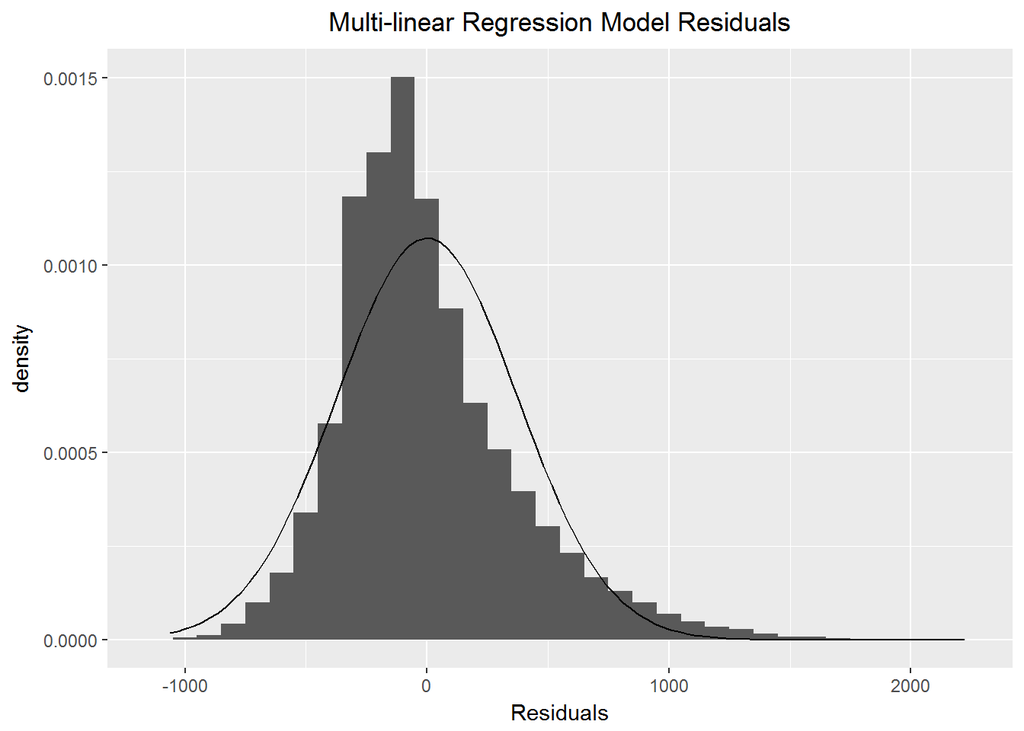

```r
ggplot(data = ST_lm_b, aes(x = resid(ST_lm_b))) + geom_histogram(binwidth = 100, position = "identity",
    aes(y = ..density..)) + stat_function(fun = dnorm, color = "black", args = list(mean = mean(ST_lm_b$residuals),
    sd(ST_lm_b$residuals))) + labs(x = "Residuals") + ggtitle("Multi-linear Regression Model Residuals") +
    theme(plot.title = element_text(hjust = 0.5))
```

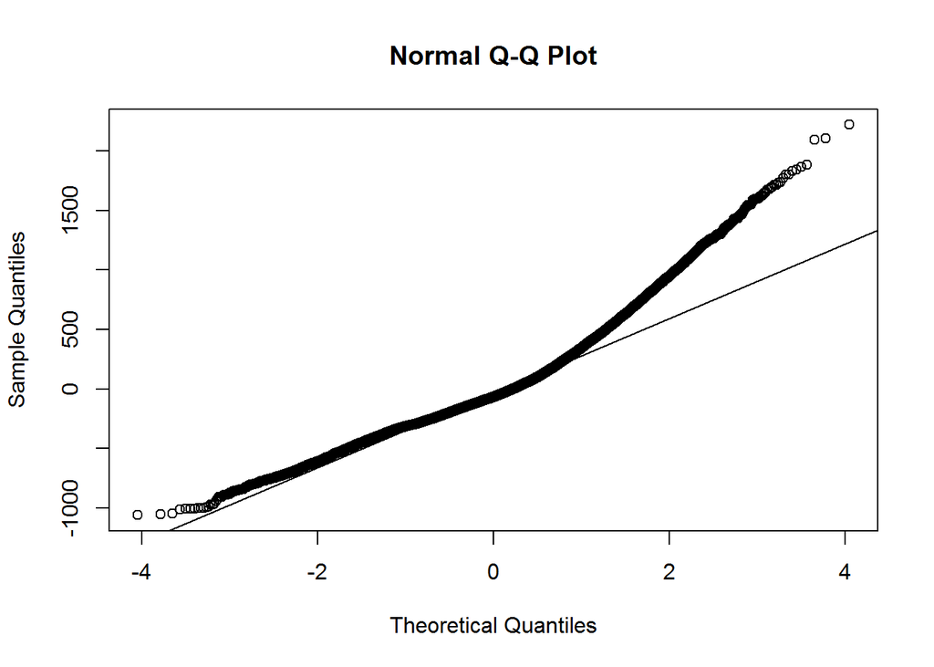

```r
qqnorm(ST_lm_b$residuals)
qqline(ST_lm_b$residuals)
```

2. the variability of the residuals is nearly constant

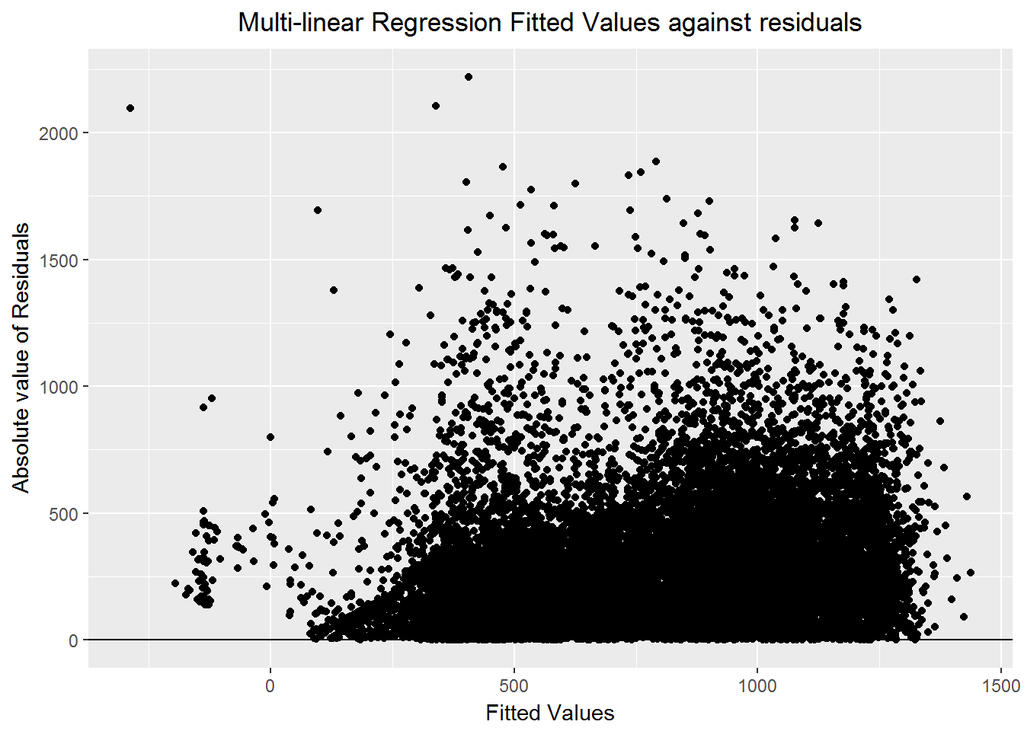

```r
ggplot(ST_lm_b, aes(y = abs(resid(ST_lm_b)), x = ST_lm_b$fitted.values)) + geom_point() + geom_hline(yintercept = 0) +
    labs(x = "Fitted Values", y = "Absolute value of Residuals") + ggtitle("Multi-linear Regression Fitted Values against residuals") +
    theme(plot.title = element_text(hjust = 0.5))
```

3. the residuals are independent

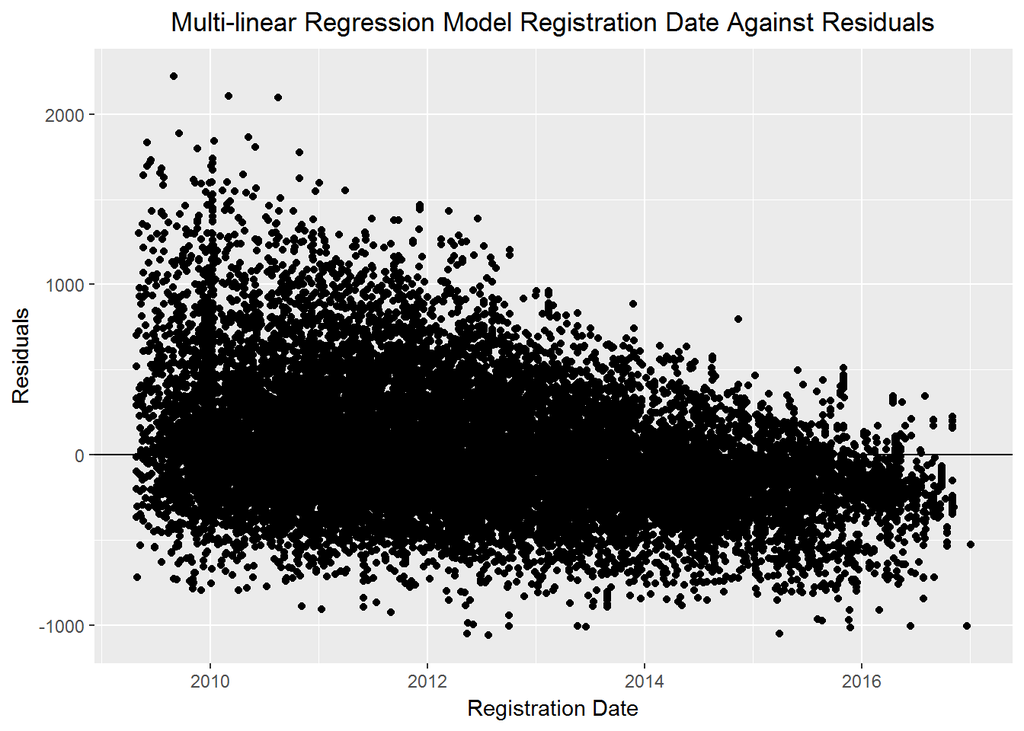

```r
ggplot(ST_lm_b, aes(y = resid(ST_lm_b), x = filtered_projects_lm$RegistrationDate)) + geom_point() +
    geom_hline(yintercept = 0) + labs(x = "Registration Date", y = "Residuals") + ggtitle("Multi-linear Regression Model Registration Date Against Residuals") +
    theme(plot.title = element_text(hjust = 0.5))
```

4. each variable is linearly related to the outcome.

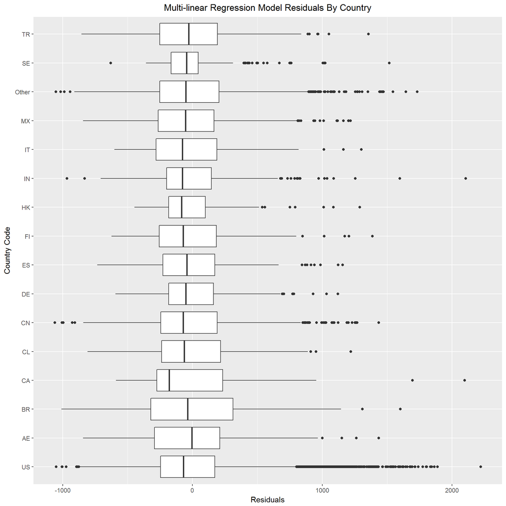

```r
ggplot(ST_lm_b, aes(y = resid(ST_lm_b), x = filtered_projects_lm$CountryAdj)) + geom_boxplot() +
    labs(x = "Country Code", y = "Residuals") + ggtitle("Multi-linear Regression Model Residuals By Country") +
    theme(plot.title = element_text(hjust = 0.5)) + coord_flip()
```

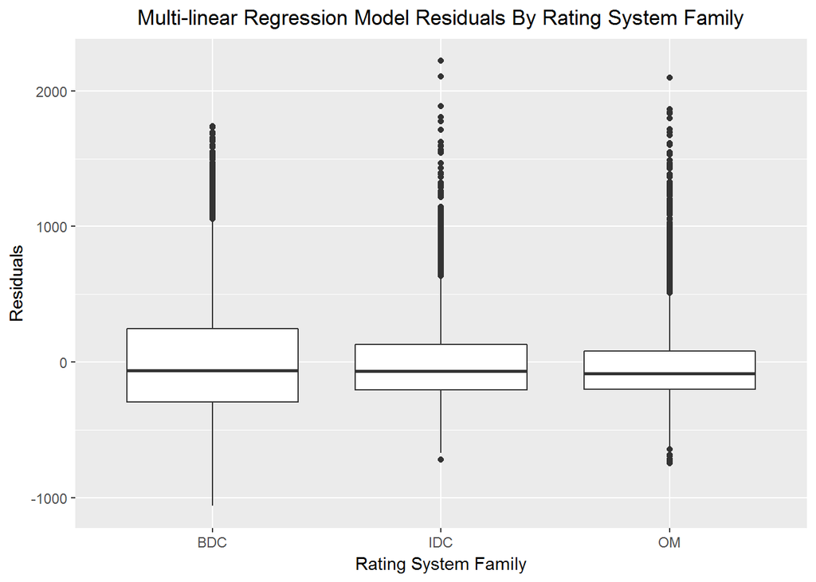

```r
ggplot(ST_lm_b, aes(y = resid(ST_lm_b), x = filtered_projects_lm$RatingSystemFamily)) + geom_boxplot() +
    labs(x = "Rating System Family", y = "Residuals") + ggtitle("Multi-linear Regression Model Residuals By Rating System Family") +
    theme(plot.title = element_text(hjust = 0.5))
```

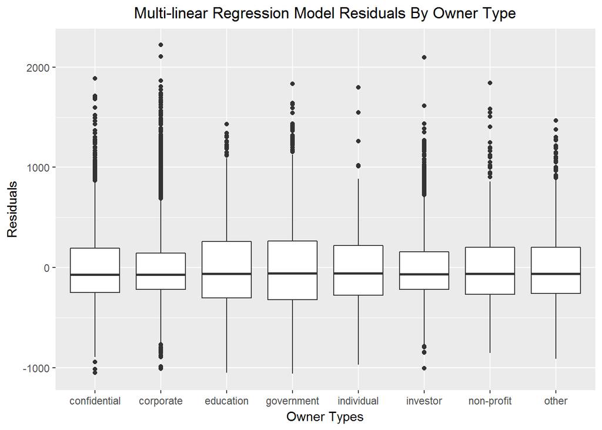

```r
ggplot(ST_lm_b, aes(y = resid(ST_lm_b), x = filtered_projects_lm$OwnerTypesAdj)) + geom_boxplot() +
    labs(x = "Owner Types", y = "Residuals") + ggtitle("Multi-linear Regression Model Residuals By Owner Type") +
    theme(plot.title = element_text(hjust = 0.5))
```

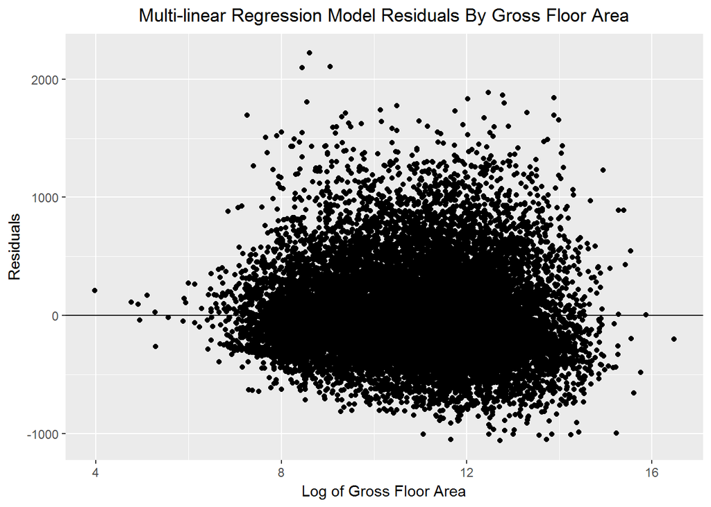

```r
ggplot(ST_lm_b, aes(y = resid(ST_lm_b), x = log(filtered_projects_lm$GrossSqFoot))) + geom_point() +
    geom_hline(yintercept = 0) + labs(x = "Log of Gross Floor Area", y = "Residuals") + ggtitle("Multi-linear Regression Model Residuals By Gross Floor Area") +
    theme(plot.title = element_text(hjust = 0.5))
```

As with the previous linear model, the residual histogram plot shows that the data distribution is more narrow than a normal distribution and has a right skew. The remaining data show that each predictor apepars to be linearly related to the outcome and appear to be independent based on the registration date graph.

### Part 5 - Conclusion:

In this analysis, we have tested the assumption that the three Rating System Families (BD+C, ID+C, OM) have a different mean time it takes to certify a project from the registration date (Submittal Time). Using an ANOVA test, we determined that at least one mean is statistically different from the set. Note, the assumptions for the ANOVA test were not entirely met since the distributions for each group do not closely follow a normal distribution; therefore, we should interpret the results with caution. A set of pairwise t-tests were then performed for each possible combination of groups which determined that all three Rating System Faimly submittal times are statistically significant from each other. All tests were performed using a significance level of $\alpha = 0.05$. Note, the t-tests were adjusted using the Bonferroni correction so that the Type I error rate is not increased ($\alpha = 0.05 / 3$).

Additionally, gross floor area was evaluated to see if it would be a good predictor variable to determine submittal time. Due to the large values, and shape of the data, a log() transformation of the values was taken for the linear regression analysis. The results of this analysis determined that gross floor area, on its own, is not a good predictor fo submittal time based on r-squared value (BD+C - 0.01, ID+C - 0.19, OM - 0.04).

To expand upon this study, we then performed a multiple regression analysis using a set of predictor variables. With this study, we determined that by using Country (Note - any countries that only had a small number of submittals have been grouped into an “other” category), Rating System Family, owner types (OwnerTypesAdj - Note - the number of categories has been significantly reduced for meaningfullness), and gross floor area (GrossSqFoot - Note this variable has been log() transformed) we have significantly improved the model which now explains 39.88% of the variability for the submittal time. However, as noted in the Inference section and at the beginning of this summary, the data appear to deviate from some of the validation assumptions; therefore, should be interpreted with caution.

For future possible adjustments to the data, we could set more aggressive cutoff submittal times that would start to limit the v3 platform data. This adjustment would help us determine what we consider a success and failure in terms of submittal times. However, we must evalute this cutoff carefully as we do not want to simply reduce the cutoff date to just “make the data fit” a normal distribution. Currently, it appears that multiple cutoff time periods would be necessary, since we have shown there is a difference in mean submittal times between Rating System Families, and the use of hierarchical modeling techniques may be necessary.

### References:

### Appendix (optional):

#### Leverage points

In the analysis, it was determined that older projects may be singificant leverage points. Since they have been open for so much longer than the newer projects, they have an increased ability to deviate from the model. Conversely, very new projects may also have singificant leverage points since we would only end up seeing projects that have certified quickly and may not represent the entire group of submittals for that time period. In a separate analysis (http://rpubs.com/john-grando/Grando-Project-Alt) I have performed the same steps as this study but with data thath excludes the oldest and youngest completed projects to evaluate the overall impact.

#### Future work

The remainder of this appendix contains additional analysis work that will be completed in the future and need not be reviewed.

```r
# Create a glm that predicts the probability of Certification.
filtered_projects$TimeOpen <- ifelse(!(is.na(filtered_projects$SubmittalTime)), filtered_projects$SubmittalTime,
    ifelse(!(is.na(filtered_projects$SubmittalTimePending)), filtered_projects$SubmittalTimePending,
        NA))

filtered_projects$IsCertifiedBol <- ifelse(filtered_projects$IsCertified == "Yes", 1, ifelse(filtered_projects$IsCertified ==
    "No", 0, NA))

filtered_projects_glm <- subset(filtered_projects, filtered_projects$TimeOpen > 0 & !(is.na(filtered_projects$Isconfidential)) &
    !(is.na(filtered_projects$Country)) & !(is.na(filtered_projects$RatingSystemFamily)) &
    !(is.na(filtered_projects$Platform)) & !(is.na(filtered_projects$OwnerTypesAdj)) & !(is.na(filtered_projects$GrossSqFoot)) &
    !(is.na(filtered_projects$IsCertifiedBol)))

# Relevel countries so that US is the reference (base) value in the linear regression.
filtered_projects_lm$Country <- as.factor(filtered_projects_lm$Country)
filtered_projects_lm$Country <- relevel(filtered_projects_lm$Country, ref = "US")

filtered_projects_glm$CountryAdj <- sapply(filtered_projects_glm$Country, function(x) {
    x <- as.character(country_count_small[which(country_count_small$Country == x), "Country"][1])
    ifelse(is.na(x), "Other", x)
})
# Relevel adjusted countries so that US is the reference (base) value in the linear
# regression.
filtered_projects_glm$CountryAdj <- as.factor(filtered_projects_glm$CountryAdj)
filtered_projects_glm$CountryAdj <- relevel(filtered_projects_glm$CountryAdj, ref = "US")


ST_glm <- glm(IsCertifiedBol ~ RatingSystemFamily + OwnerTypesAdj + CountryAdj + log(GrossSqFoot) +
    TimeOpen, data = filtered_projects_glm)
summary(ST_glm)
```

```
##
## Call:
## glm(formula = IsCertifiedBol ~ RatingSystemFamily + OwnerTypesAdj +
##     CountryAdj + log(GrossSqFoot) + TimeOpen, data = filtered_projects_glm)
##
## Deviance Residuals:
##     Min       1Q   Median       3Q      Max
## -0.9904  -0.3597  -0.1575   0.4591   1.0737
##
## Coefficients:
##                           Estimate Std. Error t value Pr(>|t|)
## (Intercept)              3.176e-01  1.469e-02  21.621  < 2e-16 ***
## RatingSystemFamilyIDC    2.260e-01  5.741e-03  39.365  < 2e-16 ***
## RatingSystemFamilyOM     6.053e-02  5.379e-03  11.253  < 2e-16 ***
## OwnerTypesAdjcorporate   2.520e-01  5.123e-03  49.192  < 2e-16 ***
## OwnerTypesAdjeducation   2.080e-01  7.675e-03  27.102  < 2e-16 ***
## OwnerTypesAdjgovernment  1.666e-01  7.087e-03  23.503  < 2e-16 ***
## OwnerTypesAdjindividual  1.870e-01  1.642e-02  11.392  < 2e-16 ***
## OwnerTypesAdjinvestor    2.228e-01  7.741e-03  28.783  < 2e-16 ***
## OwnerTypesAdjnon-profit  2.047e-01  1.172e-02  17.473  < 2e-16 ***
## OwnerTypesAdjother       1.058e-01  8.886e-03  11.909  < 2e-16 ***
## CountryAdjAE            -7.978e-02  2.218e-02  -3.597 0.000322 ***
## CountryAdjBR            -1.846e-02  1.395e-02  -1.324 0.185628
## CountryAdjCA             1.591e-01  2.417e-02   6.582 4.68e-11 ***
## CountryAdjCL            -5.024e-03  2.461e-02  -0.204 0.838224
## CountryAdjCN            -1.136e-01  9.070e-03 -12.521  < 2e-16 ***
## CountryAdjDE            -1.510e-02  1.908e-02  -0.792 0.428633
## CountryAdjES            -1.490e-01  2.073e-02  -7.191 6.53e-13 ***
## CountryAdjFI             4.390e-02  2.676e-02   1.641 0.100869
## CountryAdjHK             4.873e-02  2.930e-02   1.663 0.096329 .
## CountryAdjIN            -1.071e-01  1.419e-02  -7.545 4.58e-14 ***
## CountryAdjIT            -3.943e-02  2.385e-02  -1.653 0.098328 .
## CountryAdjMX            -1.055e-01  1.629e-02  -6.474 9.64e-11 ***
## CountryAdjOther         -1.227e-01  6.460e-03 -18.986  < 2e-16 ***
## CountryAdjSE             2.444e-01  2.500e-02   9.777  < 2e-16 ***
## CountryAdjTR            -1.114e-01  1.671e-02  -6.667 2.63e-11 ***
## log(GrossSqFoot)        -3.841e-03  1.232e-03  -3.119 0.001819 **
## TimeOpen                -1.059e-04  2.646e-06 -40.008  < 2e-16 ***
## ---
## Signif. codes:  0 '***' 0.001 '**' 0.01 '*' 0.05 '.' 0.1 ' ' 1
##
## (Dispersion parameter for gaussian family taken to be 0.196731)
##
##     Null deviance: 12308  on 53364  degrees of freedom
## Residual deviance: 10493  on 53338  degrees of freedom
## AIC: 64705
##
## Number of Fisher Scoring iterations: 2
```